# Chapter 1. PalmerPinguins dataset

Sophie Donnet

2025-01-07

```r
library(ggplot2)
library(parallel)
library(viridis)
library(dplyr)
library(knitr)
```

## 1. The Palmer penguin dataset

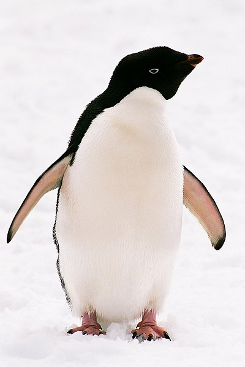

As a first illustrative example, let us consider the Palmer penguin dataset Horst, Hill, and Gorman (2020). The dataset contains several physical measurements collected on $342$ penguins from three islands in the Palmer Archipelago, Antarctica..

```r
library(palmerpenguins)
head(penguins)
```

```
## # A tibble: 6 × 8
##   species island    bill_length_mm bill_depth_mm flipper_length_mm body_mass_g
##   <fct>   <fct>              <dbl>         <dbl>             <int>       <int>
## 1 Adelie  Torgersen           39.1          18.7               181        3750
## 2 Adelie  Torgersen           39.5          17.4               186        3800
## 3 Adelie  Torgersen           40.3          18                 195        3250
## 4 Adelie  Torgersen           NA            NA                  NA          NA
## 5 Adelie  Torgersen           36.7          19.3               193        3450
## 6 Adelie  Torgersen           39.3          20.6               190        3650
## # ℹ 2 more variables: sex <fct>, year <int>
```

We focus on the measurement of bill length for $342$ penguins.

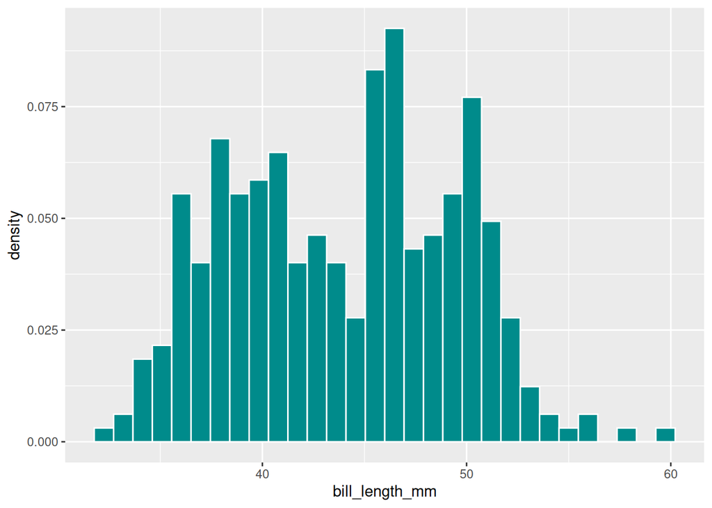

```r
library(palmerpenguins)

gg <- ggplot(penguins,aes(x=bill_length_mm,y = after_stat(density)))
gg <- gg + geom_histogram(color = "white",fill="cyan4")
gg
```

## 2. EM algorithm for 2 univariate gaussian distributions

### 2.a Functions

For `params` a list of

- `params$p`: $p$, the proportion of cluster 1
- `params$mu` $(\mu_1,\mu_2)$, the 2 means
- `params$var` : $(\sigma^2_1, \sigma^2_2)$, the two variances

we write the following functions

- `logLikelihood = function(params,y)`
- `EM_2Mixture = function(params0,y,tol=10^{-5},estim_only_mu=FALSE)`

```r
source('Functions_EM.R')
y <- penguins$bill_length_mm
y <- y[!is.na(y)]
```

### 2.b Run the EM

We now run the EM from various starting points.

```r
KM <- kmeans(y, 2)

params0 = list(list(mu=c(40,50),var=c(5,5),p=0.5),
               list(mu=c(20,50),var=c(5,5),p=0.5),
               list(mu=c(35,70),var=c(5,5),p=0.6),
               list(mu=c(50,40),var=c(10,10),p=0.4))
params0[[5]] = list(mu=c(40,50),var=c(1,1),p=0.5)
params0[[6]] = list(mu=KM$centers,var=c(3,3),p=0.5)
res_all_run_all <-do.call(rbind,lapply(1:length(params0),function(run){
  res_EM_run  <- EM_2Mixture(params0[[run]],y,tol=10^{-7},estim_only_mu = FALSE)
  niter <- nrow(res_EM_run)
  res_EM_run <- cbind(res_EM_run,rep(run,niter))
  res_EM_run <- cbind(res_EM_run, c(1:nrow(res_EM_run)))
  names(res_EM_run)[7]='Init'
  names(res_EM_run)[8]='numIter'

  return(res_EM_run)}))
```

| mu_1 | mu_2 | sigma_1_2 | sigma_2_2 | p | ll |
| --- | --- | --- | --- | --- | --- |
| 40.00000 | 50.0000 | 5 | 5 | 0.5 | -1043.558 |
| 20.00000 | 50.0000 | 5 | 5 | 0.5 | -1043.558 |
| 35.00000 | 70.0000 | 5 | 5 | 0.6 | -1053.445 |
| 50.00000 | 40.0000 | 10 | 10 | 0.4 | -1043.558 |
| 40.00000 | 50.0000 | 1 | 1 | 0.5 | -1043.558 |
| 48.49432 | 39.0741 | 3 | 3 | 0.5 | -1043.558 |

We plot the trajectories of the log-likelihood along the iterations of the algorithm starting from the initial points $\theta^{(0)}$ reported in the table.

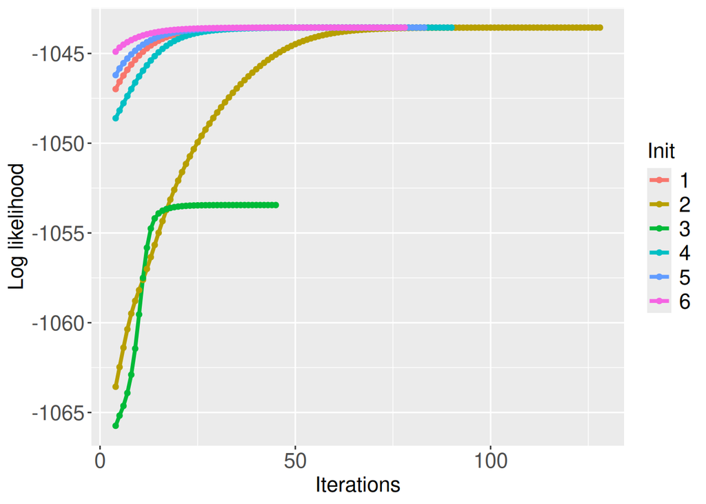

## 3. Problems of convergence

### 3.a Simulation of data

In order to illustrate a bit more the behaviour of the EM algorithm, we consider the special case where the parameters $(p,\sigma^2_{1}, \sigma^2_2)$ are known and fixed to their true value and we only want to estimate $(\mu_1,\mu_2)$. For simplicity, for this particular experiment, we simulated data $y$ with parameters
$$p=0.36 \quad \sigma^2_2 = \sigma^2_1 = 9 \quad
(\mu_1 , \mu_2) = (35,45).$$

We fix the variance to their true values and only estimate $\mu_1,\mu_2$.

```r
theta_true = list(mu = c(35, 45), var = c(9,9), p = 0.36)
```

```r
Zsim = sample(c(1,2),length(y),prob=c(theta_true$p,1-theta_true$p),replace=TRUE)
ysim = theta_true$mu[Zsim] +sqrt(theta_true$var[Zsim])*rnorm(length(y))
```

### 3.b Heatmap of the likelihood

When only estimating $\mu_1$ and $\mu_2$, we can represent the 2 variables-function $(\mu_1, \mu_2) \mapsto \log p_\theta(y)$ with a heat map as represented in the following figure.

```r
N = 600
res_like = data.frame(mu1=double(),
                      mu2 = double(),
                      ll = double())
grid_mu1 = seq(20,60,len=N)
grid_mu2 = seq(20,60,len=N)
grid_params <- as.data.frame(matrix(0,N*N,2))
names(grid_params) <- c('mu1', 'mu2')
grid_params[,1]<-  rep(grid_mu1,N)
grid_params[,2] <- rep(grid_mu2,each=N)
res_loglik <- mclapply(1:N^2,function(i){
  params.i = theta_true
  params.i$mu <- c(grid_params[i,1],grid_params[i,2])
  logLikelihood(params.i,y=ysim)},mc.cores = 4)
res_like = grid_params
res_like[,3]  = unlist(res_loglik)
names(res_like)[3] <- 'loglik'
save(res_like, file = "loglik_heatmap.Rdata")
```

Parameter maximizing the likelihood

```r
grid_params <- res_like[,c(1,2)]
wmax = which.max(res_like[,3])
grid_params[wmax,]
```

```
##            mu1      mu2
## 225228 35.1586 45.04174
```

### 3.b EM starting from several points

```r
theta0 = theta_true
params0 <- lapply(1:5,function(i){theta0})
params0[[1]]$mu = c(25,25)
params0[[2]]$mu = c(30,25)
params0[[3]]$mu = c(55,40)
params0[[4]]$mu = c(25,55)
params0[[5]]$mu = c(25,45)

res_all_run <-do.call(rbind,lapply(1:length(params0),function(run){
  res_EM_run  <- EM_2Mixture(params0[[run]],ysim,tol=10^{-5},estim_only_mu = TRUE)
  niter <- nrow(res_EM_run)
  res_EM_run <- cbind(res_EM_run,rep(run,niter))
  res_EM_run <- cbind(res_EM_run, 1:niter)
  names(res_EM_run)[7]='Init'
  names(res_EM_run)[8]='numIter'

  return(res_EM_run)}))
```

Final plot:

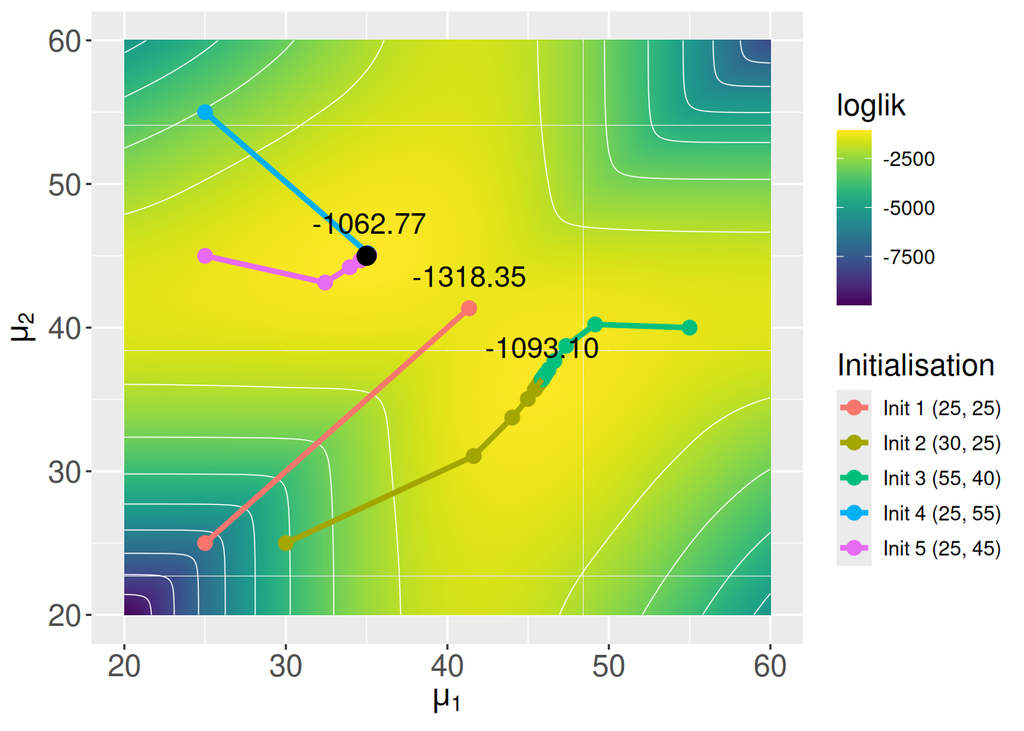

## Conclusion

In practice the EM algorithm must be initialized on several points and/or well chosen points, trying to explore various regions of the parameter space.

## References

Horst, Allison Marie, Alison Presmanes Hill, and Kristen B Gorman. 2020. *Palmerpenguins: Palmer Archipelago (Antarctica) Penguin Data*. https://doi.org/10.5281/zenodo.3960218.